# HW 01

Author

Yashi Mi

## 0 - Setup

```r
if (!require("pacman"))
  install.packages("pacman")

# use this line for installing/loading
pacman::p_load (tidyverse,
              palmerpenguins )

devtools::install_github("tidyverse/dsbox")

library(here)
```

## 1 - Road traffic accidents in Edinburgh

```r
accidents <- read_csv(here("data","accidents.csv"))
glimpse(accidents)
```

```
Rows: 768
Columns: 31
$ id                 <chr> "2018950000002", "2018950000006", "2018950000012", …
$ easting            <dbl> 327174, 324874, 330500, 321890, 320120, 331752, 325…
$ northing           <dbl> 670941, 672457, 671750, 671640, 669330, 667988, 674…
$ longitude          <dbl> -3.167032, -3.204252, -3.114026, -3.251772, -3.2794…
$ latitude           <dbl> 55.92600, 55.93926, 55.93376, 55.93145, 55.91041, 5…
$ police_force       <dbl> 95, 95, 95, 95, 95, 95, 95, 95, 95, 95, 95, 95, 95,…
$ severity           <chr> "Slight", "Slight", "Slight", "Slight", "Slight", "…
$ vehicles           <dbl> 1, 1, 2, 3, 2, 3, 1, 1, 1, 2, 2, 1, 1, 1, 2, 1, 2, …
$ casualties         <dbl> 1, 1, 2, 1, 1, 1, 2, 1, 1, 1, 1, 1, 1, 4, 1, 1, 1, …
$ date               <chr> "31/12/2018", "30/12/2018", "03/01/2018", "01/01/20…
$ day_of_week        <chr> "Monday", "Sunday", "Wednesday", "Monday", "Thursda…
$ time               <time> 14:59:00, 12:50:00, 14:34:00, 02:25:00, 09:00:00, …
$ district           <dbl> 923, 923, 923, 923, 923, 923, 923, 923, 923, 923, 9…
```

[output cut: 18 more lines]

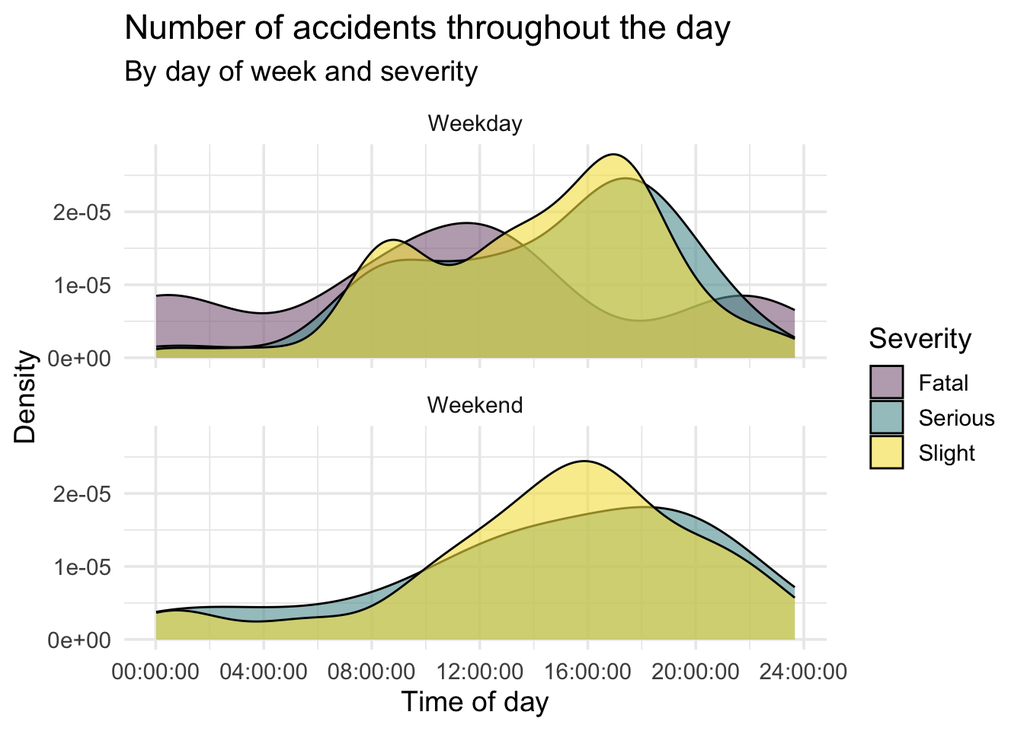

```r
accidents <- accidents |>
  mutate(day_type = case_when(
    day_of_week %in% c("Saturday", "Sunday") ~ "Weekend",
    day_of_week %in% c("Monday", "Tuesday", "Wednesday", "Thursday", "Friday") ~ "Weekday",
    TRUE ~ as.character(day_of_week)))
ggplot(accidents, aes(x = time, fill = severity)) +
  geom_density(alpha=0.6) +
  facet_wrap(~day_type, ncol=1) +
  scale_fill_manual("Severity", values = c("#8E6C8A", "#5E9CA0", "#F4E04D")) +
  labs(title = "Number of accidents throughout the day",
    subtitle = "By day of week and severity",
    x = "Time of day",
    y = "Density") +
  theme_minimal(base_size = 14)
```

**Note**

The figure illustrates the distribution of road traffic accidents in Edinburgh across different times of day, separated by weekday and weekend, and categorized by severity (Fatal, Serious, Slight).

On weekdays, the number of serious and slight accidents peaks between 16:00 and 18:00, likely corresponding to evening rush hours. Fatal accidents show a smaller peak around midday (12:00).

On weekends, the number of slight accidents also peaks around 16:00, but serious accidents tend to peak slightly later, between 18:00 and 20:00. Notably, there are no fatal accidents reported on weekends in this dataset.

## 2 - NYC marathon winners

```r
nyc_marathon <- read_csv(here("data","nyc_marathon.csv"))
glimpse(nyc_marathon)
```

```
Rows: 102
Columns: 7
$ year     <dbl> 1970, 1970, 1971, 1971, 1972, 1972, 1973, 1973, 1974, 1974, 1…
$ name     <chr> "Gary Muhrcke", NA, "Norman Higgins", "Beth Bonner", "Sheldon…
$ country  <chr> "United States", NA, "United States", "United States", "Unite…
$ time     <time> 02:31:38,       NA, 02:22:54, 02:55:22, 02:27:52, 03:08:41, …
$ time_hrs <dbl> 2.527222, NA, 2.381667, 2.922778, 2.464444, 3.144722, 2.36500…
$ division <chr> "Men", "Women", "Men", "Women", "Men", "Women", "Men", "Women…
$ note     <chr> "Course record", "No woman finishers", "Course record", "Worl…
```

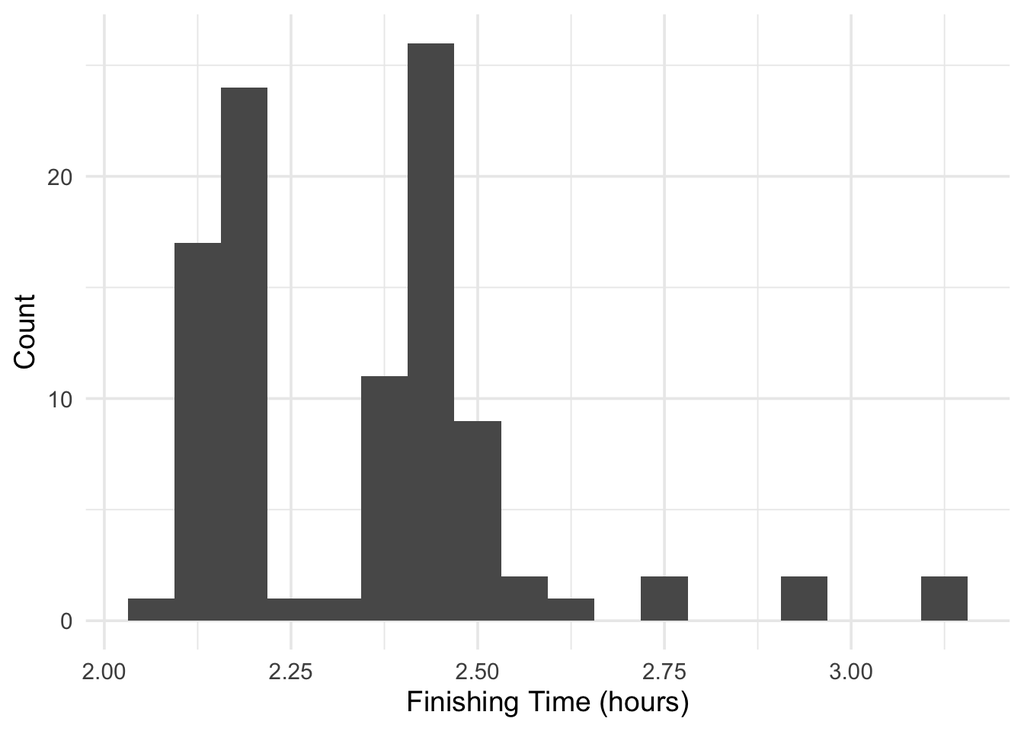

```r
nyc_marathon_clean <- nyc_marathon |>
  filter(!is.na(time_hrs))

ggplot(nyc_marathon_clean, aes(x = time_hrs))+
  geom_histogram(binwidth = 0.0625)+
   labs(x = "Finishing Time (hours)",
    y = "Count" )+
    theme_minimal(base_size = 14)
```

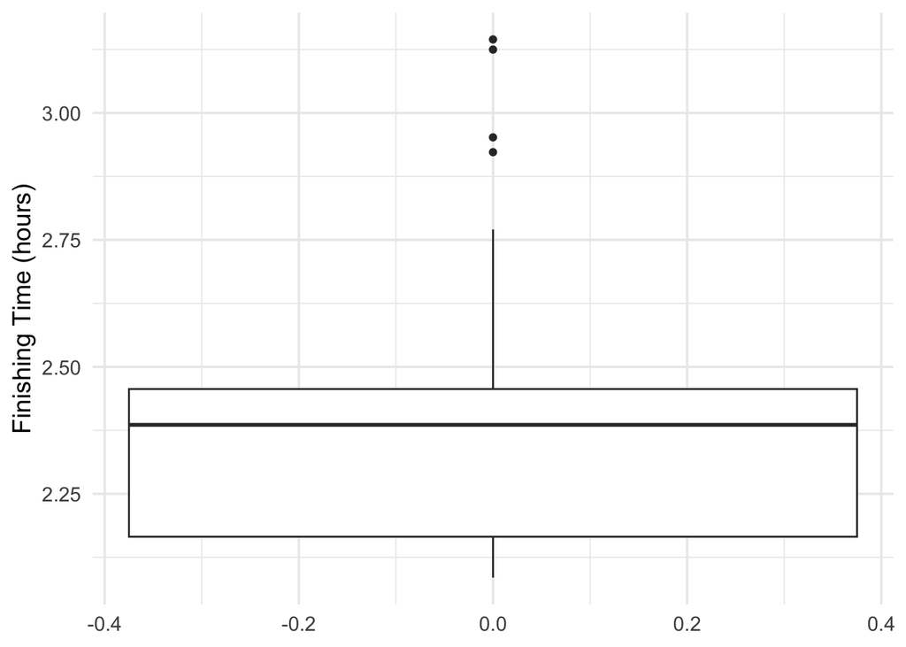

```r
ggplot(nyc_marathon_clean, aes(y = time_hrs))+
  geom_boxplot()+
   labs(y = "Finishing Time (hours)" )+
    theme_minimal(base_size = 14)
```

**Note**

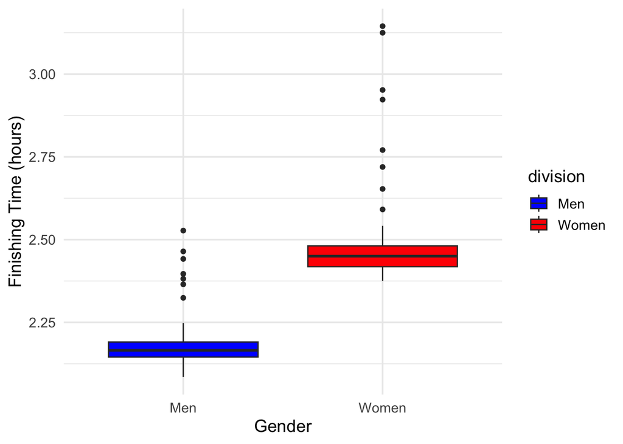

```r
ggplot(nyc_marathon_clean, aes(x = division,y = time_hrs, fill = division))+
  geom_boxplot()+
  scale_fill_manual(values = c("Blue","Red"))+
   labs(x = "Gender",
     y = "Finishing Time (hours)" )+
    theme_minimal(base_size = 14)
```

**Note**

This figure compares the distribution of marathon finishing times between male and female runners. It clearly shows that female runners tend to have longer finishing times than male runners.

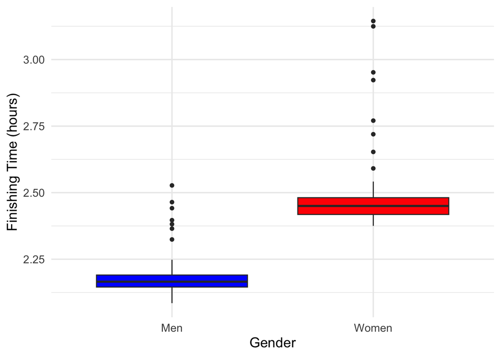

```r
ggplot(nyc_marathon_clean, aes(x = division,y = time_hrs, fill = division))+
  geom_boxplot(show.legend = FALSE)+
  scale_fill_manual(values = c("Blue","Red"))+
   labs(x = "Gender",
     y = "Finishing Time (hours)" )+
    theme_minimal(base_size = 14)
```

**Note**

Since the gender information is already clearly labeled on the x-axis, the color legend becomes redundant. Removing the legend increases the data-to-ink ratio by reducing unnecessary visual elements.

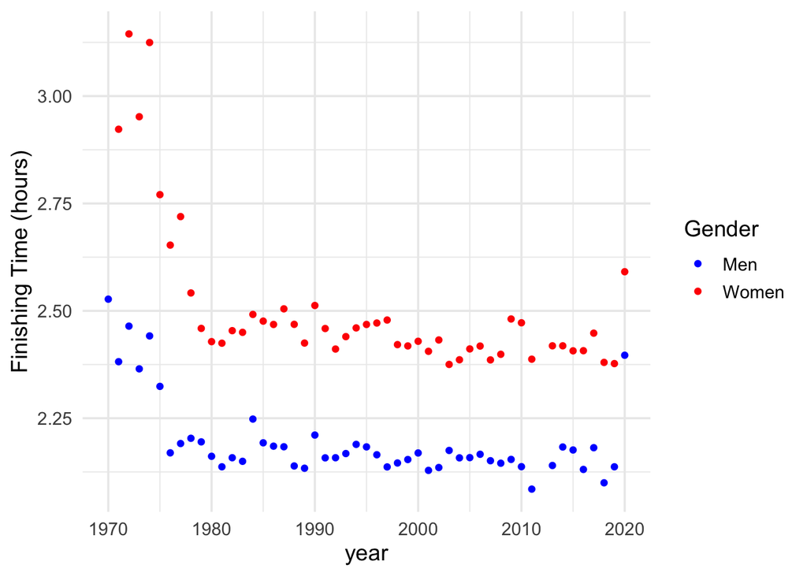

```r
ggplot(nyc_marathon_clean, aes(x = year,y = time_hrs, color   = division,shap = division))+
  geom_point(stat = "summary", fun = "mean")+
  scale_color_manual(values = c("Blue","Red")) +
  scale_shape_manual(values = c("5","7")) +
   labs(x = "year",
    y = "Finishing Time (hours)",
    color = "Gender",
    shape = "Gender")+
    theme_minimal(base_size = 14)
```

**Note**

The plot shows how marathon finishing times have changed over the past decades. It reveals a notable downward trend in finishing times for both men and women. Additionally, men consistently finished faster than women throughout the recorded years.

## 3 - US counties

**Note**

“geom_point(aes(x = median_edu, y = median_hh_income))”

This line creates a scatter plot to show the relationship between median years of education and median household income across U.S. counties.

“geom_boxplot(aes(x = smoking_ban, y = pop2017))”

This line creates a boxplot showing the distribution of 2017 population sizes grouped by smoking ban status.

**Note**

This suggests that when your goal is to compare values on the y-axis, you should place the faceting variable across columns to keep the y-axis consistent. Conversely, if you are focusing on comparisons along the x-axis, it’s better to facet across rows.

```r
library(openintro)
glimpse(county)
```

```
Rows: 3,142
Columns: 15
$ name              <chr> "Autauga County", "Baldwin County", "Barbour County"…
$ state             <fct> Alabama, Alabama, Alabama, Alabama, Alabama, Alabama…
$ pop2000           <dbl> 43671, 140415, 29038, 20826, 51024, 11714, 21399, 11…
$ pop2010           <dbl> 54571, 182265, 27457, 22915, 57322, 10914, 20947, 11…
$ pop2017           <int> 55504, 212628, 25270, 22668, 58013, 10309, 19825, 11…
$ pop_change        <dbl> 1.48, 9.19, -6.22, 0.73, 0.68, -2.28, -2.69, -1.51, …
$ poverty           <dbl> 13.7, 11.8, 27.2, 15.2, 15.6, 28.5, 24.4, 18.6, 18.8…
$ homeownership     <dbl> 77.5, 76.7, 68.0, 82.9, 82.0, 76.9, 69.0, 70.7, 71.4…
$ multi_unit        <dbl> 7.2, 22.6, 11.1, 6.6, 3.7, 9.9, 13.7, 14.3, 8.7, 4.3…
$ unemployment_rate <dbl> 3.86, 3.99, 5.90, 4.39, 4.02, 4.93, 5.49, 4.93, 4.08…
$ metro             <fct> yes, yes, no, yes, yes, no, no, yes, no, no, yes, no…
$ median_edu        <fct> some_college, some_college, hs_diploma, hs_diploma, …
$ per_capita_income <dbl> 27841.70, 27779.85, 17891.73, 20572.05, 21367.39, 15…
$ median_hh_income  <int> 55317, 52562, 33368, 43404, 47412, 29655, 36326, 436…
$ smoking_ban       <fct> none, none, partial, none, none, none, NA, NA, none,…
```

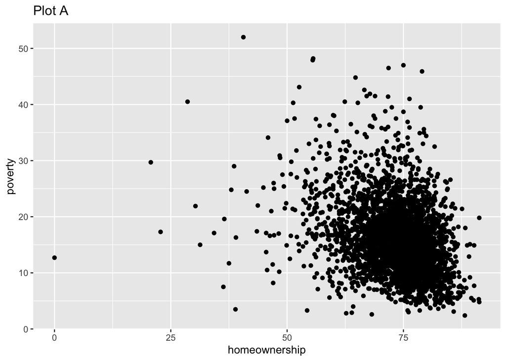

```r
county_clean <- county |>
  filter(!is.na(homeownership),!is.na(poverty))

ggplot(county_clean, aes(x = homeownership, y = poverty))+
  geom_point()+
  labs(title = "Plot A")
```

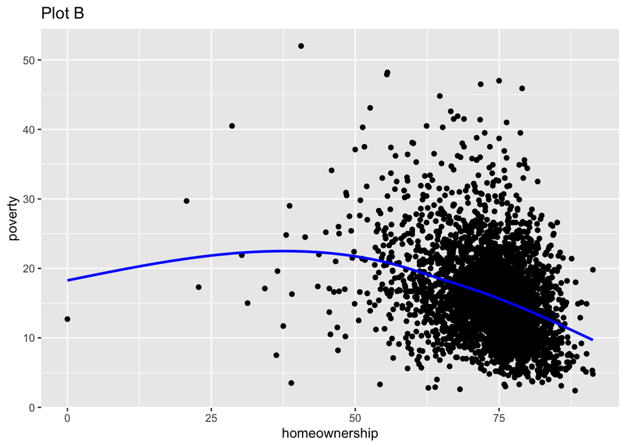

```r
ggplot(county_clean, aes(x = homeownership, y = poverty))+
  geom_point()+
  geom_smooth(method = "gam", formula = y ~ s(x, bs = "cs"), se = FALSE, color = "Blue")+
  labs(title = "Plot B")
```

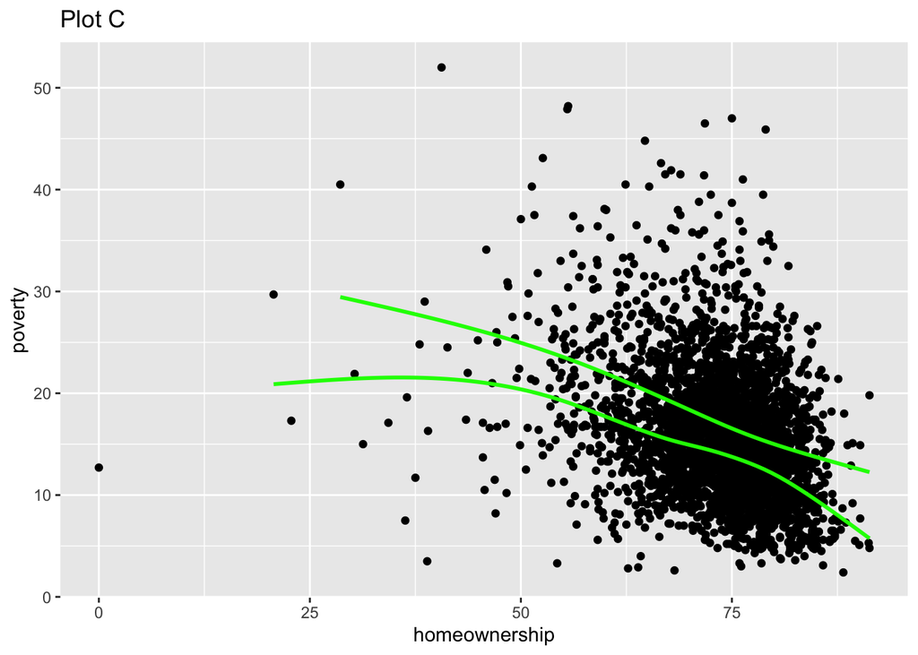

```r
ggplot(county_clean, aes(x = homeownership, y = poverty, group = metro))+
  geom_point()+
  geom_smooth(method = "gam", formula = y ~ s(x, bs = "cs"), se = FALSE, color = "Green")+
  labs(title = "Plot C")
```

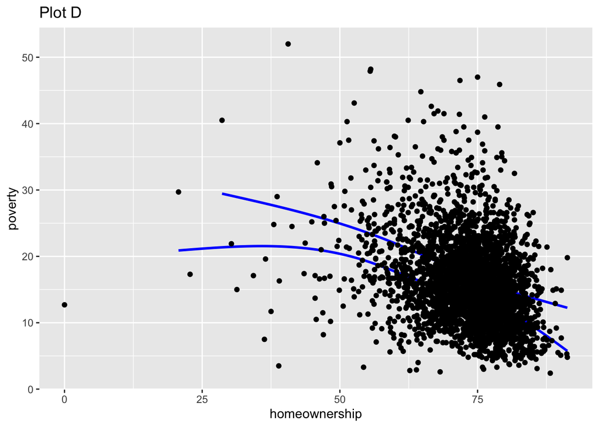

```r
ggplot(county_clean, aes(x = homeownership, y = poverty, group = metro))+
  geom_smooth(method = "gam", formula = y ~ s(x, bs = "cs"), se = FALSE, color = "Blue")+
  geom_point()+
  labs(title = "Plot D")
```

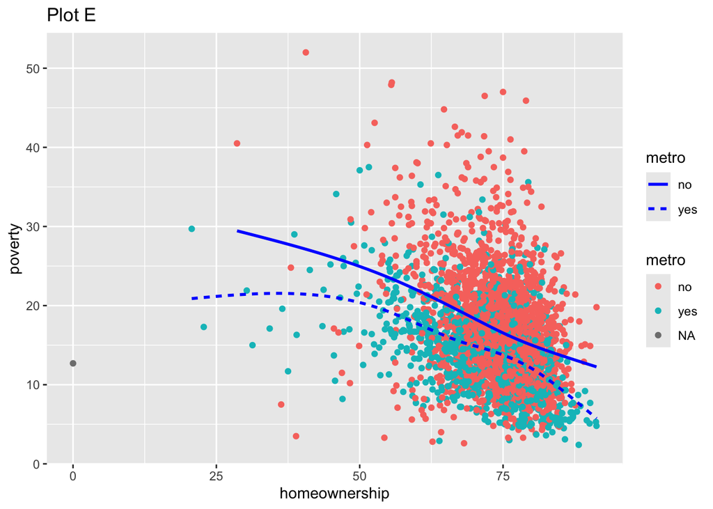

```r
ggplot(county_clean, aes(x = homeownership, y = poverty, group = metro))+
  geom_point(aes(color = metro))+
  geom_smooth(method = "gam", formula = y ~ s(x, bs = "cs"), se = FALSE, color = "Blue", aes(linetype = metro))+
  guides(color = guide_legend(order = 2),
    linetype = guide_legend(order = 1)) +
  labs(title = "Plot E")
```

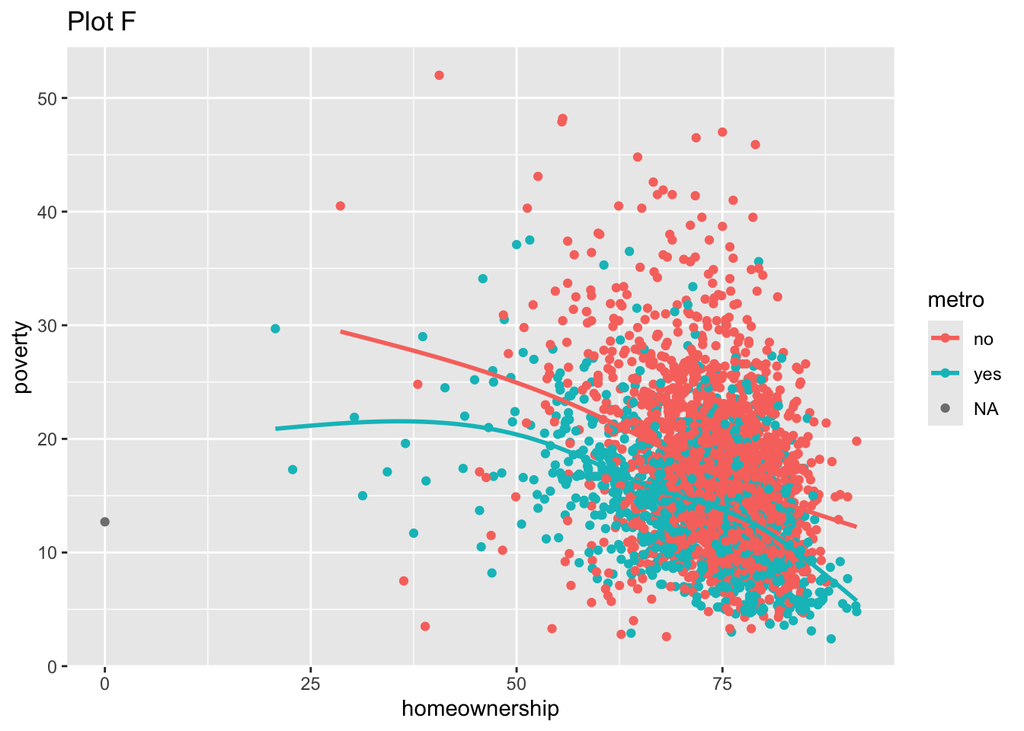

```r
ggplot(county_clean, aes(x = homeownership, y = poverty, group = metro, color =   metro))+
  geom_point()+
  geom_smooth(method = "gam", formula = y ~ s(x, bs = "cs"), se = FALSE, )+
  labs(title = "Plot F")
```

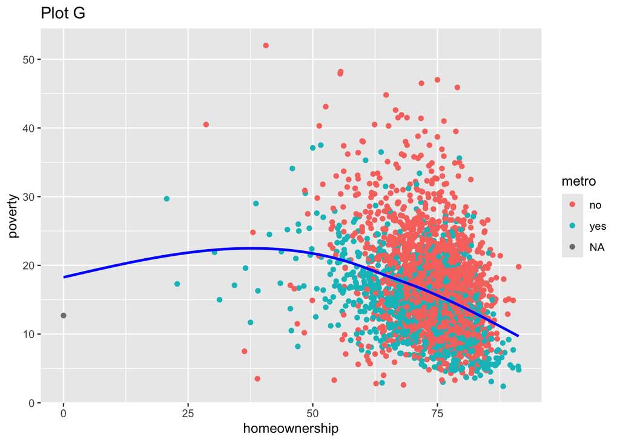

```r
ggplot(county_clean, aes(x = homeownership, y = poverty))+
  geom_point(aes(group = metro, color = metro))+
  geom_smooth(method = "gam", formula = y ~ s(x, bs = "cs"), se = FALSE, color = "Blue")+
  labs(title = "Plot G")
```

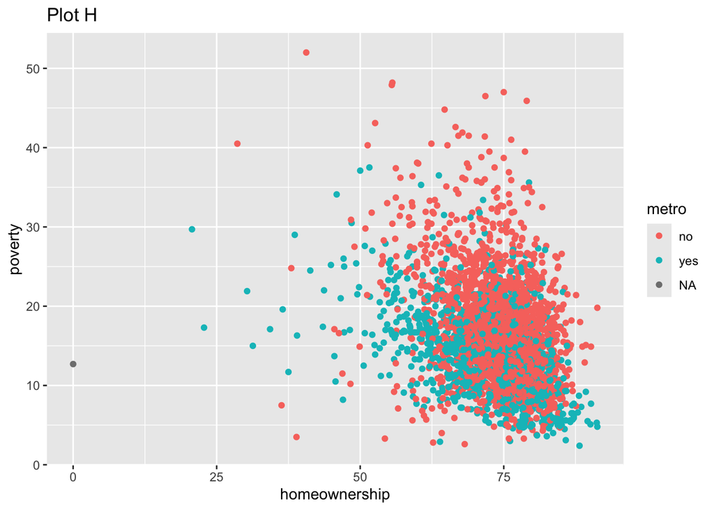

```r
ggplot(county_clean, aes(x = homeownership, y = poverty))+
  geom_point(aes(group = metro, color = metro))+
  labs(title = "Plot H")
```

## 4 - Rental apartments in SF

## 5 - Napoleon’s march.